# Udacity Machine Learning

### Question 1

#### the goal of the project

- The goal of this project to play detective, is to detect persons that might be responsible for enron's corrutption based on the emails communication among stuff, and other financial data such as salary, bonus, etc.

#### how machine learning is useful in this problem

- This will be a supervised classification problem.
- "Supervise" means there will be a bunch of samples already with labels, these somes alreay have x(features) and y(labels). Based on this, when new x(features) come in, how accurately can we predict y(label)?
- "classification" means the y(labels) will be discrete, in this case, it is yes or no, yes means the person is responsible for the corruption, and no means the person is not responsible.

#### outlier detection

- The outlier is detected and handled as below. Basically, histgram of salary, and scatter plot of salary and bonus shows a clue that there are a point that is outlier. It turned to be a sumarization row, so that that row is deleted.

```python
%matplotlib inline
import pandas as pd
import matplotlib.pyplot as plt
import pprint
import sys
import pickle
import numpy as np
import test
```

```python
### Load the dictionary containing the dataset
with open("final_project_dataset.pkl", "r") as data_file:
    data_dict = pickle.load(data_file)
```

```python
#build a pandas data frame from data_dict
df =pd.DataFrame(data_dict)
df.head(2)
```

|  | ALLEN PHILLIP K | BADUM JAMES P | BANNANTINE JAMES M | BAXTER JOHN C | BAY FRANKLIN R | BAZELIDES PHILIP J | BECK SALLY W | BELDEN TIMOTHY N | BELFER ROBERT | BERBERIAN DAVID | ... | WASAFF GEORGE | WESTFAHL RICHARD K | WHALEY DAVID A | WHALLEY LAWRENCE G | WHITE JR THOMAS E | WINOKUR JR. HERBERT S | WODRASKA JOHN | WROBEL BRUCE | YEAGER F SCOTT | YEAP SOON |
| --- | --- | --- | --- | --- | --- | --- | --- | --- | --- | --- | --- | --- | --- | --- | --- | --- | --- | --- | --- | --- | --- |
| bonus | 4175000 | NaN | NaN | 1200000 | 400000 | NaN | 700000 | 5249999 | NaN | NaN | ... | 325000 | NaN | NaN | 3000000 | 450000 | NaN | NaN | NaN | NaN | NaN |
| deferral_payments | 2869717 | 178980 | NaN | 1295738 | 260455 | 684694 | NaN | 2144013 | -102500 | NaN | ... | 831299 | NaN | NaN | NaN | NaN | NaN | NaN | NaN | NaN | NaN |

2 rows × 146 columns

```python
#transpose the data
df = df.T
print df.shape
```

```
(146, 21)
```

**Number of observation and features**

- there are 146 obeservations and 21 features.

```python
#check data types
print df.dtypes
```

```
bonus                        object
deferral_payments            object
deferred_income              object
director_fees                object
email_address                object
exercised_stock_options      object
expenses                     object
from_messages                object
from_poi_to_this_person      object
from_this_person_to_poi      object
loan_advances                object
long_term_incentive          object
other                        object
poi                          object
restricted_stock             object
restricted_stock_deferred    object
salary                       object
shared_receipt_with_poi      object
to_messages                  object
total_payments               object
total_stock_value            object
dtype: object
```

```python
##email address is the only text data, extract the email address
email_address = df.email_address
```

```python
## change all the other column into numeric type
def change_to_num( col_name):
    df[col_name] = pd.to_numeric(df[col_name], errors = 'coerce')

for name in list(df.columns):
    change_to_num(name)
```

```python
df.drop('email_address',1, inplace=True)
```

```python
print df.shape
df.describe()
```

```
(146, 20)
```

|  | bonus | deferral_payments | deferred_income | director_fees | exercised_stock_options | expenses | from_messages | from_poi_to_this_person | from_this_person_to_poi | loan_advances | long_term_incentive | other | restricted_stock | restricted_stock_deferred | salary | shared_receipt_with_poi | to_messages | total_payments | total_stock_value |
| --- | --- | --- | --- | --- | --- | --- | --- | --- | --- | --- | --- | --- | --- | --- | --- | --- | --- | --- | --- |
| count | 8.200000e+01 | 3.900000e+01 | 4.900000e+01 | 1.700000e+01 | 1.020000e+02 | 9.500000e+01 | 86.000000 | 86.000000 | 86.000000 | 4.000000e+00 | 6.600000e+01 | 9.300000e+01 | 1.100000e+02 | 1.800000e+01 | 9.500000e+01 | 86.000000 | 86.000000 | 1.250000e+02 | 1.260000e+02 |
| mean | 2.374235e+06 | 1.642674e+06 | -1.140475e+06 | 1.668049e+05 | 5.987054e+06 | 1.087289e+05 | 608.790698 | 64.895349 | 41.232558 | 4.196250e+07 | 1.470361e+06 | 9.190650e+05 | 2.321741e+06 | 1.664106e+05 | 5.621943e+05 | 1176.465116 | 2073.860465 | 5.081526e+06 | 6.773957e+06 |
| std | 1.071333e+07 | 5.161930e+06 | 4.025406e+06 | 3.198914e+05 | 3.106201e+07 | 5.335348e+05 | 1841.033949 | 86.979244 | 100.073111 | 4.708321e+07 | 5.942759e+06 | 4.589253e+06 | 1.251828e+07 | 4.201494e+06 | 2.716369e+06 | 1178.317641 | 2582.700981 | 2.906172e+07 | 3.895777e+07 |
| min | 7.000000e+04 | -1.025000e+05 | -2.799289e+07 | 3.285000e+03 | 3.285000e+03 | 1.480000e+02 | 12.000000 | 0.000000 | 0.000000 | 4.000000e+05 | 6.922300e+04 | 2.000000e+00 | -2.604490e+06 | -7.576788e+06 | 4.770000e+02 | 2.000000 | 57.000000 | 1.480000e+02 | -4.409300e+04 |
| 25% | 4.312500e+05 | 8.157300e+04 | -6.948620e+05 | 9.878400e+04 | 5.278862e+05 | 2.261400e+04 | 22.750000 | 10.000000 | 1.000000 | 1.600000e+06 | 2.812500e+05 | 1.215000e+03 | 2.540180e+05 | -3.896218e+05 | 2.118160e+05 | 249.750000 | 541.250000 | 3.944750e+05 | 4.945102e+05 |
| 50% | 7.693750e+05 | 2.274490e+05 | -1.597920e+05 | 1.085790e+05 | 1.310814e+06 | 4.695000e+04 | 41.000000 | 35.000000 | 8.000000 | 4.176250e+07 | 4.420350e+05 | 5.238200e+04 | 4.517400e+05 | -1.469750e+05 | 2.599960e+05 | 740.500000 | 1211.000000 | 1.101393e+06 | 1.102872e+06 |
| 75% | 1.200000e+06 | 1.002672e+06 | -3.834600e+04 | 1.137840e+05 | 2.547724e+06 | 7.995250e+04 | 145.500000 | 72.250000 | 24.750000 | 8.212500e+07 | 9.386720e+05 | 3.620960e+05 | 1.002370e+06 | -7.500975e+04 | 3.121170e+05 | 1888.250000 | 2634.750000 | 2.093263e+06 | 2.949847e+06 |
| max | 9.734362e+07 | 3.208340e+07 | -8.330000e+02 | 1.398517e+06 | 3.117640e+08 | 5.235198e+06 | 14368.000000 | 528.000000 | 609.000000 | 8.392500e+07 | 4.852193e+07 | 4.266759e+07 | 1.303223e+08 | 1.545629e+07 | 2.670423e+07 | 5521.000000 | 15149.000000 | 3.098866e+08 | 4.345095e+08 |

```python
df.info()
```

```
<class 'pandas.core.frame.DataFrame'>
Index: 146 entries, ALLEN PHILLIP K to YEAP SOON
Data columns (total 20 columns):
bonus                        82 non-null float64
deferral_payments            39 non-null float64
deferred_income              49 non-null float64
director_fees                17 non-null float64
exercised_stock_options      102 non-null float64
expenses                     95 non-null float64
from_messages                86 non-null float64
from_poi_to_this_person      86 non-null float64
from_this_person_to_poi      86 non-null float64
loan_advances                4 non-null float64
long_term_incentive          66 non-null float64
other                        93 non-null float64
poi                          146 non-null bool
restricted_stock             110 non-null float64
restricted_stock_deferred    18 non-null float64
salary                       95 non-null float64
shared_receipt_with_poi      86 non-null float64
to_messages                  86 non-null float64
total_payments               125 non-null float64
total_stock_value            126 non-null float64
dtypes: bool(1), float64(19)
memory usage: 28.0+ KB
```

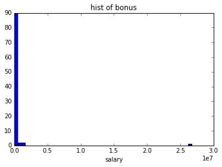

```python
plt.hist((df.salary).dropna(), bins=50)
plt.xlabel('salary')
plt.title('hist of bonus')
plt.show()
```

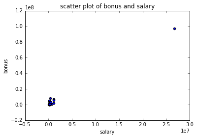

```python
plt.scatter(df.salary,df.bonus)
plt.xlabel('salary')
plt.ylabel('bonus')
plt.title('scatter plot of bonus and salary')
plt.show()
```

**Comments**: It seems like for both bonus and salary, there is one point that is a outlier. Is it possible it appears in every columns? Check the column extreme for each column

```python
df.idxmax(axis=0, skipna=True)
```

```
bonus                                      TOTAL
deferral_payments                          TOTAL
deferred_income               BOWEN JR RAYMOND M
director_fees                              TOTAL
exercised_stock_options                    TOTAL
expenses                                   TOTAL
from_messages                KAMINSKI WINCENTY J
from_poi_to_this_person          LAVORATO JOHN J
from_this_person_to_poi         DELAINEY DAVID W
loan_advances                              TOTAL
long_term_incentive                        TOTAL
other                                      TOTAL
poi                             BELDEN TIMOTHY N
restricted_stock                           TOTAL
restricted_stock_deferred       BHATNAGAR SANJAY
salary                                     TOTAL
shared_receipt_with_poi         BELDEN TIMOTHY N
to_messages                    SHAPIRO RICHARD S
total_payments                             TOTAL
total_stock_value                          TOTAL
dtype: object
```

**comment**: "TOTAL" row appears most, inspect the total row

```python
df.ix["TOTAL",:]
```

```
bonus                        9.73436e+07
deferral_payments            3.20834e+07
deferred_income             -2.79929e+07
director_fees                1.39852e+06
exercised_stock_options      3.11764e+08
expenses                      5.2352e+06
from_messages                        NaN
from_poi_to_this_person              NaN
from_this_person_to_poi              NaN
loan_advances                 8.3925e+07
long_term_incentive          4.85219e+07
other                        4.26676e+07
poi                                False
restricted_stock             1.30322e+08
restricted_stock_deferred   -7.57679e+06
salary                       2.67042e+07
shared_receipt_with_poi              NaN
to_messages                          NaN
total_payments               3.09887e+08
total_stock_value             4.3451e+08
Name: TOTAL, dtype: object
```

```python
df.median()
```

```
bonus                          769375.0
deferral_payments              227449.0
deferred_income               -159792.0
director_fees                  108579.0
exercised_stock_options       1310813.5
expenses                        46950.0
from_messages                      41.0
from_poi_to_this_person            35.0
from_this_person_to_poi             8.0
loan_advances                41762500.0
long_term_incentive            442035.0
other                           52382.0
poi                                 0.0
restricted_stock               451740.0
restricted_stock_deferred     -146975.0
salary                         259996.0
shared_receipt_with_poi           740.5
to_messages                      1211.0
total_payments                1101393.0
total_stock_value             1102872.5
dtype: float64
```

#### About the TOTAL observation

the total observation seems to be an excel addup row, it is actually not a real observation.

```python
df.drop("TOTAL", inplace=True)
df.shape
```

```
(145, 20)
```

```
[18, 127]
```

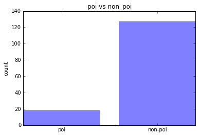

```python
objects = ['poi','non-poi']
y_pos = np.arange(2)
performance = [df[df.poi ==1 ].shape[0],df[df.poi ==0].shape[0] ]

print performance
plt.bar(y_pos, performance, align='center', alpha=0.5)
plt.xticks(y_pos, objects)
plt.ylabel('count')
plt.title('poi vs non_poi')

plt.show()
```

### label counts

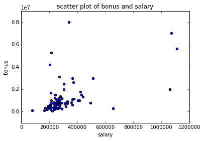

```python
# after delete the row "TOTAL", replot
plt.scatter(df.salary,df.bonus)
plt.ylabel('bonus')
plt.xlabel('salary')
plt.title('scatter plot of bonus and salary')
plt.show()
```

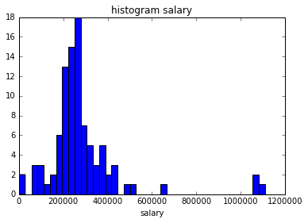

```python
plt.hist(df.salary.dropna(), bins =40)
plt.xlabel('salary')
plt.title('histogram salary')
plt.show()
```

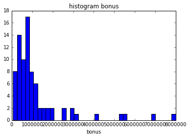

```python
plt.hist(df.bonus.dropna(), bins =40)
plt.xlabel('bonus')
plt.title('histogram bonus')
plt.show()
```

#### after the outlier is deleted, the scatter plot of bonus and salary is "normal"

### Question2

#### feature scaling

- I did feature scaling, as the numeric feature show large difference in range. For email related features, they are in tens or hundreds, but for finance related features, they are much bigger than that. For algorithm that are based on distance metrics, such as KNN, feature scaling is crutial.

#### feature engineering

- I created new feature bonus_salary_ratio
- The rational behind it is that: I thought people who are responsible for the company's corruption might be the one who is the top person, who can normally get more bonus. but normally the bonus should be in proportion with someone's salary. If the bonus_salary_ratio is out of range, that means that person could have super power in the company, and be responsible for the company's corruption.

#### feature importance

- if feature is unscaled

- if feature is scaled

[('exercised_stock_options', 0.11517186463132585), ('deferred_income', 0.095259273370553385), ('total_stock_value', 0.094631524527654248), ('restricted_stock', 0.085888055967725654), ('bonus_salary_ratio', 0.084666251609632079), ('shared_receipt_with_poi', 0.080914857087832706), ('from_this_person_to_poi', 0.068359600187301389), ('bonus', 0.055545110165006392), ('salary', 0.048681560652220249), ('from_poi_to_this_person', 0.041443463487798468), ('deferral_payments', 0.038257852352547965), ('other', 0.032596980204839615), ('total_payments', 0.029643930981528271), ('expenses', 0.029439246890876503), ('long_term_incentive', 0.029404783683353829), ('to_messages', 0.028286820037558974), ('from_messages', 0.022213235368438972), ('restricted_stock_deferred', 0.0096742811650759927), ('loan_advances', 0.0062142857142857113), ('director_fees', 0.0037070219144437803)]

```python
#na values, can not scale, so replace all na with 0
df.fillna(value=0, inplace=True)
```

### train test split, and feature can be either scaled or not

```python
from sklearn import cross_validation
from sklearn import preprocessing

def train_test_feature_label_split(features, labels, scale=False):
    features_train, features_test, labels_train, labels_test = \
cross_validation.train_test_split(features, labels, test_size=0.3, random_state=1)

    if scale:
        min_max_scaler = preprocessing.MinMaxScaler()
        feature_train = min_max_scaler.fit_transform(features_train)
        feature_test = min_max_scaler.fit_transform(features_test)

    return (features_train, features_test, labels_train, labels_test)
```

#### feature engineering: bonus_salary_ratio

```python
def create_bonus_salary_ratio(row):
    if row['bonus'] == 0 or row['salary'] ==0:
        return 0
    else:
        return row['bonus']/row['salary']

df['bonus_salary_ratio'] = df.apply(create_bonus_salary_ratio, axis=1)
```

### using the full feature list and order the feature importance by using extratree classifier

```python
labels = df['poi']
## full list of features list here for select
features_list = [
'bonus',
'deferral_payments',
'deferred_income',
'director_fees',
'exercised_stock_options',
'expenses',
'from_messages',
'from_poi_to_this_person',
'from_this_person_to_poi',
'loan_advances',
'long_term_incentive',
'other',
'restricted_stock',
'restricted_stock_deferred',
'salary',
'shared_receipt_with_poi',
'to_messages',
'total_payments',
'total_stock_value',
'bonus_salary_ratio']
features = df[features_list]
```

```python
from sklearn import metrics
from sklearn.ensemble import ExtraTreesClassifier
from sklearn.model_selection import StratifiedShuffleSplit
from sklearn import preprocessing

def get_feature_importance(features, labels,scale = False):

    importance_list = []
    min_max_scaler = preprocessing.MinMaxScaler()
    sss = StratifiedShuffleSplit(n_splits=1000, test_size=0.5, random_state=0)
    sss.get_n_splits(features, labels)

    for train_index, test_index in sss.split(features, labels):
        labels_train, labels_test = labels.ix[train_index], labels.ix[test_index]
        if not scale:
            features_train, features_test = features.ix[train_index,:], features.ix[test_index,:]
        else:
            features_train, features_test = features.ix[train_index,:], features.ix[test_index,:]
            features_train = min_max_scaler.fit_transform(features_train)
            features_test = min_max_scaler.fit_transform(features_test)

        # fit an Extra Trees model to the data
        clf = ExtraTreesClassifier()
        clf.fit(features_train,labels_train)
    # display the relative importance of each attribute
        importance = clf.feature_importances_
        features_list = list(features.columns)
        importance_dict=dict(zip(features_list,importance))
        importance_list.append(importance_dict)

    df = pd.DataFrame(importance_list)
    return df
```

```python
feature_importance_df=get_feature_importance(features, labels,scale = False)
```

```python
feature_importance_df.mean().to_dict()
```

```
{'bonus': 0.072034387527509694,
 'bonus_salary_ratio': 0.060452841172045989,
 'deferral_payments': 0.021924924749344987,
 'deferred_income': 0.079203332277574007,
 'director_fees': 0.0011977213093799053,
 'exercised_stock_options': 0.093626173115234759,
 'expenses': 0.063045121391368905,
 'from_messages': 0.029340591271030083,
 'from_poi_to_this_person': 0.055166187750737943,
 'from_this_person_to_poi': 0.051422343045004697,
 'loan_advances': 0.0076549151692186616,
 'long_term_incentive': 0.056164001286775414,
 'other': 0.066450253876289944,
 'restricted_stock': 0.058320153940616126,
 'restricted_stock_deferred': 0.0045121438742657853,
 'salary': 0.056968620841718533,
 'shared_receipt_with_poi': 0.053111828656602994,
 'to_messages': 0.034168632677089236,
 'total_payments': 0.049233168088635607,
 'total_stock_value': 0.086002657979556821}
```

```python
ordered_dict =sorted(feature_importance_df.mean().to_dict().items(),key=lambda t: -t[1])
pprint.pprint(ordered_dict)
```

```
[('exercised_stock_options', 0.093626173115234759),
 ('total_stock_value', 0.086002657979556821),
 ('deferred_income', 0.079203332277574007),
 ('bonus', 0.072034387527509694),
 ('other', 0.066450253876289944),
 ('expenses', 0.063045121391368905),
 ('bonus_salary_ratio', 0.060452841172045989),
 ('restricted_stock', 0.058320153940616126),
 ('salary', 0.056968620841718533),
 ('long_term_incentive', 0.056164001286775414),
 ('from_poi_to_this_person', 0.055166187750737943),
 ('shared_receipt_with_poi', 0.053111828656602994),
 ('from_this_person_to_poi', 0.051422343045004697),
 ('total_payments', 0.049233168088635607),
 ('to_messages', 0.034168632677089236),
 ('from_messages', 0.029340591271030083),
 ('deferral_payments', 0.021924924749344987),
 ('loan_advances', 0.0076549151692186616),
 ('restricted_stock_deferred', 0.0045121438742657853),
 ('director_fees', 0.0011977213093799053)]
```

```python
order_dict_df = pd.DataFrame(ordered_dict)
```

```python
order_dict_df
```

|  | 0 | 1 |
| --- | --- | --- |
| 0 | exercised_stock_options | 0.093626 |
| 1 | total_stock_value | 0.086003 |
| 2 | deferred_income | 0.079203 |
| 3 | bonus | 0.072034 |
| 4 | other | 0.066450 |
| 5 | expenses | 0.063045 |
| 6 | bonus_salary_ratio | 0.060453 |
| 7 | restricted_stock | 0.058320 |
| 8 | salary | 0.056969 |
| 9 | long_term_incentive | 0.056164 |
| 10 | from_poi_to_this_person | 0.055166 |
| 11 | shared_receipt_with_poi | 0.053112 |
| 12 | from_this_person_to_poi | 0.051422 |
| 13 | total_payments | 0.049233 |
| 14 | to_messages | 0.034169 |
| 15 | from_messages | 0.029341 |
| 16 | deferral_payments | 0.021925 |
| 17 | loan_advances | 0.007655 |
| 18 | restricted_stock_deferred | 0.004512 |
| 19 | director_fees | 0.001198 |

```python
objects = order_dict_df.ix[:,0]
objects
```

```
0       exercised_stock_options
1             total_stock_value
2               deferred_income
3                         bonus
4                         other
5                      expenses
6            bonus_salary_ratio
7              restricted_stock
8                        salary
9           long_term_incentive
10      from_poi_to_this_person
11      shared_receipt_with_poi
12      from_this_person_to_poi
13               total_payments
14                  to_messages
15                from_messages
16            deferral_payments
17                loan_advances
18    restricted_stock_deferred
19                director_fees
Name: 0, dtype: object
```

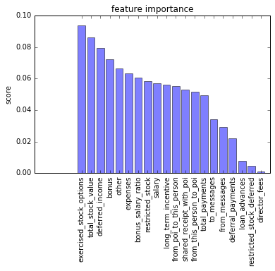

```python
objects = order_dict_df.ix[:,0]
y_pos = np.arange(20)
performance = order_dict_df.ix[:,1]

plt.bar(y_pos, performance, align='center', alpha=0.5)
plt.xticks(y_pos, objects)
plt.ylabel('score')
plt.title('feature importance')
plt.xticks(rotation=90)

plt.show()
```

## feature selection_step one

```python
top13=order_dict_df.ix[:,0][:13]
```

## use naive bayes to test out features, from the top of the list, gradually add one more feature, watch the precision and recall change.

```python
top13[:1]
```

```
0    exercised_stock_options
Name: 0, dtype: object
```

```python
list_of_feature_frames = []
for i in range(1,14):
    list_of_feature_frames.append(df[top13[:i]])
```

```python
from sklearn.naive_bayes import GaussianNB
from sklearn.metrics import accuracy_score
clf = GaussianNB()
precision_recall_list =[]
for i in range(13):
    precision_recall = test.test_classifier(list_of_feature_frames[i], labels, clf, scaled= False)
    precision_recall_list.append(precision_recall)
precision_recall_df = pd.DataFrame(precision_recall_list)
```

```
dim of features are
(145, 1)
true_negatives count is 18541
false_negatives count is 1995
false_positives count is 659
true_positives count is 705
==========================================
GaussianNB(priors=None)
	Accuracy: 0.87881	Precision: 0.51686	Recall: 0.26111	F1: 0.34695	F2: 0.28979
	Total predictions: 21900	True positives:  705	False positives:  659	False negatives: 1995	True negatives: 18541

dim of features are
(145, 2)
true_negatives count is 18297
false_negatives count is 1968
false_positives count is 903
true_positives count is 732
==========================================
GaussianNB(priors=None)
	Accuracy: 0.86890	Precision: 0.44771	Recall: 0.27111	F1: 0.33772	F2: 0.29433
	Total predictions: 21900	True positives:  732	False positives:  903	False negatives: 1968	True negatives: 18297

dim of features are
(145, 3)
true_negatives count is 18151
false_negatives count is 1738
false_positives count is 1049
true_positives count is 962
==========================================
GaussianNB(priors=None)
	Accuracy: 0.87274	Precision: 0.47837	Recall: 0.35630	F1: 0.40841	F2: 0.37546
	Total predictions: 21900	True positives:  962	False positives: 1049	False negatives: 1738	True negatives: 18151

dim of features are
(145, 4)
true_negatives count is 17986
false_negatives count is 1739
false_positives count is 1214
true_positives count is 961
==========================================
```

[output cut: 87 more lines]

```
==========================================
GaussianNB(priors=None)
	Accuracy: 0.84078	Precision: 0.34742	Recall: 0.33185	F1: 0.33946	F2: 0.33485
	Total predictions: 21900	True positives:  896	False positives: 1683	False negatives: 1804	True negatives: 17517

dim of features are
(145, 13)
true_negatives count is 17542
false_negatives count is 1818
false_positives count is 1658
true_positives count is 882
==========================================
GaussianNB(priors=None)
	Accuracy: 0.84128	Precision: 0.34724	Recall: 0.32667	F1: 0.33664	F2: 0.33058
	Total predictions: 21900	True positives:  882	False positives: 1658	False negatives: 1818	True negatives: 17542
```

```python
index_names = []
for i in range(13):
    index_names.append("top_{}".format(i+1))
precision_recall_df.index = index_names
```

```python
precision_recall_df['pr_sum'] = precision_recall_df.precision+precision_recall_df.recall
```

```python
precision_recall_df.pr_sum.max(axis=0)
```

```
0.83466526695765886
```

```python
index_ = list(precision_recall_df.pr_sum).index(precision_recall_df.pr_sum.max(axis=0))
```

```python
precision_recall_df.index[index_]
```

```
'top_3'
```

## feature selection_step two

### my feature selection test experiment shows that when I only include the top 3 features, the sum of precision and recall are the biggest, therefore, I will only include the top three features in my following algorithms test. The top three features are:

- 'deferred_income'
- 'exercised_stock_options'
- 'total_stock_value'

```python
selected_feature_list = ['deferred_income',
                         'exercised_stock_options',
                         'total_stock_value',
                         ]
selected_features = df[selected_feature_list]

selected_feature_list_with_ratio = ['bonus_salary_ratio',
                         'deferred_income',
                         'exercised_stock_options',
                         'total_stock_value',
                         ]
selected_features_with_ratio = df[selected_feature_list_with_ratio]
labels = df.poi
```

## try out different machine learning algorithms

```python
from sklearn.naive_bayes import GaussianNB
from sklearn.metrics import accuracy_score
clf = GaussianNB()
```

```python
test.test_classifier(selected_features, labels, clf, scaled= False)
```

```
dim of features are
(145, 3)
true_negatives count is 18151
false_negatives count is 1738
false_positives count is 1049
true_positives count is 962
==========================================
GaussianNB(priors=None)
	Accuracy: 0.87274	Precision: 0.47837	Recall: 0.35630	F1: 0.40841	F2: 0.37546
	Total predictions: 21900	True positives:  962	False positives: 1049	False negatives: 1738	True negatives: 18151
```

```
{'precision': 0.4783689706613625, 'recall': 0.3562962962962963}
```

```python
test.test_classifier(selected_features, labels, clf, scaled= True)
```

```
dim of features are
(145, 3)
true_negatives count is 17868
false_negatives count is 1768
false_positives count is 1332
true_positives count is 932
==========================================
GaussianNB(priors=None)
	Accuracy: 0.85845	Precision: 0.41166	Recall: 0.34519	F1: 0.37550	F2: 0.35671
	Total predictions: 21900	True positives:  932	False positives: 1332	False negatives: 1768	True negatives: 17868
```

```
{'precision': 0.411660777385159, 'recall': 0.3451851851851852}
```

```python
test.test_classifier(selected_features_with_ratio, labels, clf, scaled= False)
```

```
dim of features are
(145, 4)
true_negatives count is 18151
false_negatives count is 1738
false_positives count is 1049
true_positives count is 962
==========================================
GaussianNB(priors=None)
	Accuracy: 0.87274	Precision: 0.47837	Recall: 0.35630	F1: 0.40841	F2: 0.37546
	Total predictions: 21900	True positives:  962	False positives: 1049	False negatives: 1738	True negatives: 18151
```

```
{'precision': 0.4783689706613625, 'recall': 0.3562962962962963}
```

```python
test.test_classifier(selected_features_with_ratio, labels, clf, scaled= True)
```

```
dim of features are
(145, 4)
true_negatives count is 17724
false_negatives count is 1808
false_positives count is 1476
true_positives count is 892
==========================================
GaussianNB(priors=None)
	Accuracy: 0.85005	Precision: 0.37669	Recall: 0.33037	F1: 0.35201	F2: 0.33870
	Total predictions: 21900	True positives:  892	False positives: 1476	False negatives: 1808	True negatives: 17724
```

```
{'precision': 0.3766891891891892, 'recall': 0.33037037037037037}
```

```python
from sklearn import tree
from sklearn.feature_selection import RFE
clf = tree.DecisionTreeClassifier(min_samples_split=2)
```

```python
test.test_classifier(selected_features, labels, clf, scaled= False)
```

```
dim of features are
(145, 3)
true_negatives count is 17195
false_negatives count is 2020
false_positives count is 2005
true_positives count is 680
==========================================
DecisionTreeClassifier(class_weight=None, criterion='gini', max_depth=None,
            max_features=None, max_leaf_nodes=None,
            min_impurity_split=1e-07, min_samples_leaf=1,
            min_samples_split=2, min_weight_fraction_leaf=0.0,
            presort=False, random_state=None, splitter='best')
	Accuracy: 0.81621	Precision: 0.25326	Recall: 0.25185	F1: 0.25255	F2: 0.25213
	Total predictions: 21900	True positives:  680	False positives: 2005	False negatives: 2020	True negatives: 17195
```

```
{'precision': 0.2532588454376164, 'recall': 0.2518518518518518}
```

```python
test.test_classifier(selected_features, labels, clf, scaled= True)
```

```
dim of features are
(145, 3)
true_negatives count is 17107
false_negatives count is 1940
false_positives count is 2093
true_positives count is 760
==========================================
DecisionTreeClassifier(class_weight=None, criterion='gini', max_depth=None,
            max_features=None, max_leaf_nodes=None,
            min_impurity_split=1e-07, min_samples_leaf=1,
            min_samples_split=2, min_weight_fraction_leaf=0.0,
            presort=False, random_state=None, splitter='best')
	Accuracy: 0.81584	Precision: 0.26639	Recall: 0.28148	F1: 0.27373	F2: 0.27833
	Total predictions: 21900	True positives:  760	False positives: 2093	False negatives: 1940	True negatives: 17107
```

```
{'precision': 0.2663862600771118, 'recall': 0.2814814814814815}
```

```python
test.test_classifier(selected_features_with_ratio, labels, clf, scaled= False)
```

```
dim of features are
(145, 4)
true_negatives count is 17422
false_negatives count is 1937
false_positives count is 1778
true_positives count is 763
==========================================
DecisionTreeClassifier(class_weight=None, criterion='gini', max_depth=None,
            max_features=None, max_leaf_nodes=None,
            min_impurity_split=1e-07, min_samples_leaf=1,
            min_samples_split=2, min_weight_fraction_leaf=0.0,
            presort=False, random_state=None, splitter='best')
	Accuracy: 0.83037	Precision: 0.30028	Recall: 0.28259	F1: 0.29117	F2: 0.28596
	Total predictions: 21900	True positives:  763	False positives: 1778	False negatives: 1937	True negatives: 17422
```

```
{'precision': 0.3002754820936639, 'recall': 0.2825925925925926}
```

```python
test.test_classifier(selected_features_with_ratio, labels, clf, scaled= True)
```

```
dim of features are
(145, 4)
true_negatives count is 17248
false_negatives count is 1858
false_positives count is 1952
true_positives count is 842
==========================================
DecisionTreeClassifier(class_weight=None, criterion='gini', max_depth=None,
            max_features=None, max_leaf_nodes=None,
            min_impurity_split=1e-07, min_samples_leaf=1,
            min_samples_split=2, min_weight_fraction_leaf=0.0,
            presort=False, random_state=None, splitter='best')
	Accuracy: 0.82603	Precision: 0.30136	Recall: 0.31185	F1: 0.30652	F2: 0.30970
	Total predictions: 21900	True positives:  842	False positives: 1952	False negatives: 1858	True negatives: 17248
```

```
{'precision': 0.3013600572655691, 'recall': 0.3118518518518518}
```

```python
from sklearn.ensemble import RandomForestClassifier
clf = RandomForestClassifier(n_estimators=100)
test.test_classifier(selected_features, labels, clf, scaled= False)
```

```
dim of features are
(145, 3)
true_negatives count is 18717
false_negatives count is 2304
false_positives count is 483
true_positives count is 396
==========================================
RandomForestClassifier(bootstrap=True, class_weight=None, criterion='gini',
            max_depth=None, max_features='auto', max_leaf_nodes=None,
            min_impurity_split=1e-07, min_samples_leaf=1,
            min_samples_split=2, min_weight_fraction_leaf=0.0,
            n_estimators=100, n_jobs=1, oob_score=False, random_state=None,
            verbose=0, warm_start=False)
	Accuracy: 0.87274	Precision: 0.45051	Recall: 0.14667	F1: 0.22129	F2: 0.16954
	Total predictions: 21900	True positives:  396	False positives:  483	False negatives: 2304	True negatives: 18717
```

```
{'precision': 0.45051194539249145, 'recall': 0.14666666666666667}
```

```python
test.test_classifier(selected_features, labels, clf, scaled= True)
```

```
dim of features are
(145, 3)
true_negatives count is 18496
false_negatives count is 2211
false_positives count is 704
true_positives count is 489
==========================================
RandomForestClassifier(bootstrap=True, class_weight=None, criterion='gini',
            max_depth=None, max_features='auto', max_leaf_nodes=None,
            min_impurity_split=1e-07, min_samples_leaf=1,
            min_samples_split=2, min_weight_fraction_leaf=0.0,
            n_estimators=100, n_jobs=1, oob_score=False, random_state=None,
            verbose=0, warm_start=False)
	Accuracy: 0.86689	Precision: 0.40989	Recall: 0.18111	F1: 0.25122	F2: 0.20387
	Total predictions: 21900	True positives:  489	False positives:  704	False negatives: 2211	True negatives: 18496
```

```
{'precision': 0.4098910310142498, 'recall': 0.1811111111111111}
```

```python
test.test_classifier(selected_features_with_ratio, labels, clf, scaled= False)
```

```
dim of features are
(145, 4)
true_negatives count is 18648
false_negatives count is 2194
false_positives count is 552
true_positives count is 506
==========================================
RandomForestClassifier(bootstrap=True, class_weight=None, criterion='gini',
            max_depth=None, max_features='auto', max_leaf_nodes=None,
            min_impurity_split=1e-07, min_samples_leaf=1,
            min_samples_split=2, min_weight_fraction_leaf=0.0,
            n_estimators=100, n_jobs=1, oob_score=False, random_state=None,
            verbose=0, warm_start=False)
	Accuracy: 0.87461	Precision: 0.47826	Recall: 0.18741	F1: 0.26929	F2: 0.21336
	Total predictions: 21900	True positives:  506	False positives:  552	False negatives: 2194	True negatives: 18648
```

```
{'precision': 0.4782608695652174, 'recall': 0.1874074074074074}
```

```python
test.test_classifier(selected_features_with_ratio, labels, clf, scaled= True)
```

```
dim of features are
(145, 4)
true_negatives count is 18426
false_negatives count is 2115
false_positives count is 774
true_positives count is 585
==========================================
RandomForestClassifier(bootstrap=True, class_weight=None, criterion='gini',
            max_depth=None, max_features='auto', max_leaf_nodes=None,
            min_impurity_split=1e-07, min_samples_leaf=1,
            min_samples_split=2, min_weight_fraction_leaf=0.0,
            n_estimators=100, n_jobs=1, oob_score=False, random_state=None,
            verbose=0, warm_start=False)
	Accuracy: 0.86808	Precision: 0.43046	Recall: 0.21667	F1: 0.28825	F2: 0.24056
	Total predictions: 21900	True positives:  585	False positives:  774	False negatives: 2115	True negatives: 18426
```

```
{'precision': 0.4304635761589404, 'recall': 0.21666666666666667}
```

```python
##neural_network
from sklearn.neural_network import MLPClassifier
clf = MLPClassifier(solver='lbfgs', alpha=1e-5,
                    hidden_layer_sizes=(3, 3), random_state=1)
test.test_classifier(selected_features, labels, clf, scaled= False)
```

```
dim of features are
(145, 3)
true_negatives count is 19062
false_negatives count is 2700
false_positives count is 138
true_positives count is 0
==========================================
Got a divide by zero when trying out: MLPClassifier(activation='relu', alpha=1e-05, batch_size='auto', beta_1=0.9,
       beta_2=0.999, early_stopping=False, epsilon=1e-08,
       hidden_layer_sizes=(3, 3), learning_rate='constant',
       learning_rate_init=0.001, max_iter=200, momentum=0.9,
       nesterovs_momentum=True, power_t=0.5, random_state=1, shuffle=True,
       solver='lbfgs', tol=0.0001, validation_fraction=0.1, verbose=False,
       warm_start=False)
Precision or recall may be undefined due to a lack of true positive predicitons.
++++++++++++++++++++++++++++++++++++++
```

```
{'precision': 0.0, 'recall': 0.0}
```

```python
test.test_classifier(selected_features, labels, clf, scaled= False)
```

```
dim of features are
(145, 3)
true_negatives count is 19062
false_negatives count is 2700
false_positives count is 138
true_positives count is 0
==========================================
Got a divide by zero when trying out: MLPClassifier(activation='relu', alpha=1e-05, batch_size='auto', beta_1=0.9,
       beta_2=0.999, early_stopping=False, epsilon=1e-08,
       hidden_layer_sizes=(3, 3), learning_rate='constant',
       learning_rate_init=0.001, max_iter=200, momentum=0.9,
       nesterovs_momentum=True, power_t=0.5, random_state=1, shuffle=True,
       solver='lbfgs', tol=0.0001, validation_fraction=0.1, verbose=False,
       warm_start=False)
Precision or recall may be undefined due to a lack of true positive predicitons.
++++++++++++++++++++++++++++++++++++++
```

```
{'precision': 0.0, 'recall': 0.0}
```

```python
test.test_classifier(selected_features_with_ratio, labels, clf, scaled= True)
```

```
dim of features are
(145, 4)
true_negatives count is 18408
false_negatives count is 2322
false_positives count is 792
true_positives count is 378
==========================================
MLPClassifier(activation='relu', alpha=1e-05, batch_size='auto', beta_1=0.9,
       beta_2=0.999, early_stopping=False, epsilon=1e-08,
       hidden_layer_sizes=(3, 3), learning_rate='constant',
       learning_rate_init=0.001, max_iter=200, momentum=0.9,
       nesterovs_momentum=True, power_t=0.5, random_state=1, shuffle=True,
       solver='lbfgs', tol=0.0001, validation_fraction=0.1, verbose=False,
       warm_start=False)
	Accuracy: 0.85781	Precision: 0.32308	Recall: 0.14000	F1: 0.19535	F2: 0.15789
	Total predictions: 21900	True positives:  378	False positives:  792	False negatives: 2322	True negatives: 18408
```

```
{'precision': 0.3230769230769231, 'recall': 0.14}
```

```python
test.test_classifier(selected_features_with_ratio, labels, clf, scaled= False)
```

```
dim of features are
(145, 4)
true_negatives count is 17385
false_negatives count is 2423
false_positives count is 1815
true_positives count is 277
==========================================
MLPClassifier(activation='relu', alpha=1e-05, batch_size='auto', beta_1=0.9,
       beta_2=0.999, early_stopping=False, epsilon=1e-08,
       hidden_layer_sizes=(3, 3), learning_rate='constant',
       learning_rate_init=0.001, max_iter=200, momentum=0.9,
       nesterovs_momentum=True, power_t=0.5, random_state=1, shuffle=True,
       solver='lbfgs', tol=0.0001, validation_fraction=0.1, verbose=False,
       warm_start=False)
	Accuracy: 0.80648	Precision: 0.13241	Recall: 0.10259	F1: 0.11561	F2: 0.10743
	Total predictions: 21900	True positives:  277	False positives: 1815	False negatives: 2423	True negatives: 17385
```

```
{'precision': 0.13240917782026768, 'recall': 0.1025925925925926}
```

```python
#logistic regression
from sklearn import linear_model
clf = linear_model.LogisticRegression()
test.test_classifier(selected_features, labels, clf, scaled= False)
```

```
dim of features are
(145, 3)
true_negatives count is 13933
false_negatives count is 2300
false_positives count is 5267
true_positives count is 400
==========================================
LogisticRegression(C=1.0, class_weight=None, dual=False, fit_intercept=True,
          intercept_scaling=1, max_iter=100, multi_class='ovr', n_jobs=1,
          penalty='l2', random_state=None, solver='liblinear', tol=0.0001,
          verbose=0, warm_start=False)
	Accuracy: 0.65447	Precision: 0.07058	Recall: 0.14815	F1: 0.09561	F2: 0.12146
	Total predictions: 21900	True positives:  400	False positives: 5267	False negatives: 2300	True negatives: 13933
```

```
{'precision': 0.07058408328921828, 'recall': 0.14814814814814814}
```

```python
test.test_classifier(selected_features, labels, clf, scaled= True)
```

```
dim of features are
(145, 3)
true_negatives count is 19138
false_negatives count is 2607
false_positives count is 62
true_positives count is 93
==========================================
LogisticRegression(C=1.0, class_weight=None, dual=False, fit_intercept=True,
          intercept_scaling=1, max_iter=100, multi_class='ovr', n_jobs=1,
          penalty='l2', random_state=None, solver='liblinear', tol=0.0001,
          verbose=0, warm_start=False)
	Accuracy: 0.87813	Precision: 0.60000	Recall: 0.03444	F1: 0.06515	F2: 0.04245
	Total predictions: 21900	True positives:   93	False positives:   62	False negatives: 2607	True negatives: 19138
```

```
{'precision': 0.6, 'recall': 0.034444444444444444}
```

```python
test.test_classifier(selected_features_with_ratio, labels, clf, scaled= False)
```

```
dim of features are
(145, 4)
true_negatives count is 14024
false_negatives count is 2303
false_positives count is 5176
true_positives count is 397
==========================================
LogisticRegression(C=1.0, class_weight=None, dual=False, fit_intercept=True,
          intercept_scaling=1, max_iter=100, multi_class='ovr', n_jobs=1,
          penalty='l2', random_state=None, solver='liblinear', tol=0.0001,
          verbose=0, warm_start=False)
	Accuracy: 0.65849	Precision: 0.07124	Recall: 0.14704	F1: 0.09597	F2: 0.12124
	Total predictions: 21900	True positives:  397	False positives: 5176	False negatives: 2303	True negatives: 14024
```

```
{'precision': 0.07123631796160057, 'recall': 0.14703703703703705}
```

```python
test.test_classifier(selected_features_with_ratio, labels, clf, scaled= True)
```

```
dim of features are
(145, 4)
true_negatives count is 19088
false_negatives count is 2591
false_positives count is 112
true_positives count is 109
==========================================
LogisticRegression(C=1.0, class_weight=None, dual=False, fit_intercept=True,
          intercept_scaling=1, max_iter=100, multi_class='ovr', n_jobs=1,
          penalty='l2', random_state=None, solver='liblinear', tol=0.0001,
          verbose=0, warm_start=False)
	Accuracy: 0.87658	Precision: 0.49321	Recall: 0.04037	F1: 0.07463	F2: 0.04945
	Total predictions: 21900	True positives:  109	False positives:  112	False negatives: 2591	True negatives: 19088
```

```
{'precision': 0.49321266968325794, 'recall': 0.04037037037037037}
```

```python
##KNN
from sklearn import neighbors
clf = neighbors.KNeighborsClassifier(n_neighbors=4, weights ='distance')
test.test_classifier(selected_features, labels, clf, scaled= False)
```

```
dim of features are
(145, 3)
true_negatives count is 18667
false_negatives count is 2342
false_positives count is 533
true_positives count is 358
==========================================
KNeighborsClassifier(algorithm='auto', leaf_size=30, metric='minkowski',
           metric_params=None, n_jobs=1, n_neighbors=4, p=2,
           weights='distance')
	Accuracy: 0.86872	Precision: 0.40180	Recall: 0.13259	F1: 0.19939	F2: 0.15311
	Total predictions: 21900	True positives:  358	False positives:  533	False negatives: 2342	True negatives: 18667
```

```
{'precision': 0.40179573512906847, 'recall': 0.1325925925925926}
```

```python
test.test_classifier(selected_features, labels, clf, scaled= True)
```

```
dim of features are
(145, 3)
true_negatives count is 18263
false_negatives count is 2261
false_positives count is 937
true_positives count is 439
==========================================
KNeighborsClassifier(algorithm='auto', leaf_size=30, metric='minkowski',
           metric_params=None, n_jobs=1, n_neighbors=4, p=2,
           weights='distance')
	Accuracy: 0.85397	Precision: 0.31904	Recall: 0.16259	F1: 0.21541	F2: 0.18027
	Total predictions: 21900	True positives:  439	False positives:  937	False negatives: 2261	True negatives: 18263
```

```
{'precision': 0.3190406976744186, 'recall': 0.1625925925925926}
```

```python
test.test_classifier(selected_features_with_ratio, labels, clf, scaled= False)
```

```
dim of features are
(145, 4)
true_negatives count is 18667
false_negatives count is 2342
false_positives count is 533
true_positives count is 358
==========================================
KNeighborsClassifier(algorithm='auto', leaf_size=30, metric='minkowski',
           metric_params=None, n_jobs=1, n_neighbors=4, p=2,
           weights='distance')
	Accuracy: 0.86872	Precision: 0.40180	Recall: 0.13259	F1: 0.19939	F2: 0.15311
	Total predictions: 21900	True positives:  358	False positives:  533	False negatives: 2342	True negatives: 18667
```

```
{'precision': 0.40179573512906847, 'recall': 0.1325925925925926}
```

```python
test.test_classifier(selected_features_with_ratio, labels, clf, scaled= True)
```

```
dim of features are
(145, 4)
true_negatives count is 18438
false_negatives count is 2203
false_positives count is 762
true_positives count is 497
==========================================
KNeighborsClassifier(algorithm='auto', leaf_size=30, metric='minkowski',
           metric_params=None, n_jobs=1, n_neighbors=4, p=2,
           weights='distance')
	Accuracy: 0.86461	Precision: 0.39476	Recall: 0.18407	F1: 0.25107	F2: 0.20607
	Total predictions: 21900	True positives:  497	False positives:  762	False negatives: 2203	True negatives: 18438
```

```
{'precision': 0.3947577442414615, 'recall': 0.18407407407407408}
```

```python
from sklearn.neighbors.nearest_centroid import NearestCentroid
clf = NearestCentroid(shrink_threshold=0.05)
test.test_classifier(selected_features, labels, clf, scaled= False)
```

```
dim of features are
(145, 3)
true_negatives count is 17031
false_negatives count is 1821
false_positives count is 2169
true_positives count is 879
==========================================
NearestCentroid(metric='euclidean', shrink_threshold=0.05)
	Accuracy: 0.81781	Precision: 0.28839	Recall: 0.32556	F1: 0.30585	F2: 0.31737
	Total predictions: 21900	True positives:  879	False positives: 2169	False negatives: 1821	True negatives: 17031
```

```
{'precision': 0.28838582677165353, 'recall': 0.32555555555555554}
```

```python
test.test_classifier(selected_features, labels, clf, scaled= True)
```

```
dim of features are
(145, 3)
true_negatives count is 17390
false_negatives count is 1674
false_positives count is 1810
true_positives count is 1026
==========================================
NearestCentroid(metric='euclidean', shrink_threshold=0.05)
	Accuracy: 0.84091	Precision: 0.36178	Recall: 0.38000	F1: 0.37066	F2: 0.37621
	Total predictions: 21900	True positives: 1026	False positives: 1810	False negatives: 1674	True negatives: 17390
```

```
{'precision': 0.3617771509167842, 'recall': 0.38}
```

```python
test.test_classifier(selected_features_with_ratio, labels, clf, scaled= False)
```

```
dim of features are
(145, 4)
true_negatives count is 17037
false_negatives count is 1821
false_positives count is 2163
true_positives count is 879
==========================================
NearestCentroid(metric='euclidean', shrink_threshold=0.05)
	Accuracy: 0.81808	Precision: 0.28895	Recall: 0.32556	F1: 0.30617	F2: 0.31751
	Total predictions: 21900	True positives:  879	False positives: 2163	False negatives: 1821	True negatives: 17037
```

```
{'precision': 0.28895463510848124, 'recall': 0.32555555555555554}
```

```python
test.test_classifier(selected_features_with_ratio, labels, clf, scaled= True)
```

```
dim of features are
(145, 4)
true_negatives count is 17322
false_negatives count is 1601
false_positives count is 1878
true_positives count is 1099
==========================================
NearestCentroid(metric='euclidean', shrink_threshold=0.05)
	Accuracy: 0.84114	Precision: 0.36916	Recall: 0.40704	F1: 0.38718	F2: 0.39885
	Total predictions: 21900	True positives: 1099	False positives: 1878	False negatives: 1601	True negatives: 17322
```

```
{'precision': 0.36916358750419886, 'recall': 0.40703703703703703}
```

```python
##adaboost
from sklearn.ensemble import AdaBoostClassifier
from sklearn.tree import DecisionTreeClassifier
clf = AdaBoostClassifier(DecisionTreeClassifier(max_depth=1),learning_rate=0.3,
                         algorithm="SAMME",
                         n_estimators=200)
test.test_classifier(selected_features, labels, clf, scaled= False)
```

```
dim of features are
(145, 3)
true_negatives count is 18475
false_negatives count is 2121
false_positives count is 725
true_positives count is 579
==========================================
AdaBoostClassifier(algorithm='SAMME',
          base_estimator=DecisionTreeClassifier(class_weight=None, criterion='gini', max_depth=1,
            max_features=None, max_leaf_nodes=None,
            min_impurity_split=1e-07, min_samples_leaf=1,
            min_samples_split=2, min_weight_fraction_leaf=0.0,
            presort=False, random_state=None, splitter='best'),
          learning_rate=0.3, n_estimators=200, random_state=None)
	Accuracy: 0.87005	Precision: 0.44402	Recall: 0.21444	F1: 0.28921	F2: 0.23918
	Total predictions: 21900	True positives:  579	False positives:  725	False negatives: 2121	True negatives: 18475
```

```
{'precision': 0.44401840490797545, 'recall': 0.21444444444444444}
```

```python
test.test_classifier(selected_features, labels, clf, scaled= True)
```

```
dim of features are
(145, 3)
true_negatives count is 18402
false_negatives count is 2080
false_positives count is 798
true_positives count is 620
==========================================
AdaBoostClassifier(algorithm='SAMME',
          base_estimator=DecisionTreeClassifier(class_weight=None, criterion='gini', max_depth=1,
            max_features=None, max_leaf_nodes=None,
            min_impurity_split=1e-07, min_samples_leaf=1,
            min_samples_split=2, min_weight_fraction_leaf=0.0,
            presort=False, random_state=None, splitter='best'),
          learning_rate=0.3, n_estimators=200, random_state=None)
	Accuracy: 0.86858	Precision: 0.43724	Recall: 0.22963	F1: 0.30112	F2: 0.25372
	Total predictions: 21900	True positives:  620	False positives:  798	False negatives: 2080	True negatives: 18402
```

```
{'precision': 0.43723554301833567, 'recall': 0.22962962962962963}
```

```python
test.test_classifier(selected_features_with_ratio, labels, clf, scaled= False)
```

```
dim of features are
(145, 4)
true_negatives count is 18288
false_negatives count is 2115
false_positives count is 912
true_positives count is 585
==========================================
AdaBoostClassifier(algorithm='SAMME',
          base_estimator=DecisionTreeClassifier(class_weight=None, criterion='gini', max_depth=1,
            max_features=None, max_leaf_nodes=None,
            min_impurity_split=1e-07, min_samples_leaf=1,
            min_samples_split=2, min_weight_fraction_leaf=0.0,
            presort=False, random_state=None, splitter='best'),
          learning_rate=0.3, n_estimators=200, random_state=None)
	Accuracy: 0.86178	Precision: 0.39078	Recall: 0.21667	F1: 0.27877	F2: 0.23786
	Total predictions: 21900	True positives:  585	False positives:  912	False negatives: 2115	True negatives: 18288
```

```
{'precision': 0.3907815631262525, 'recall': 0.21666666666666667}
```

```python
test.test_classifier(selected_features_with_ratio, labels, clf, scaled= True)
```

```
dim of features are
(145, 4)
true_negatives count is 18099
false_negatives count is 2019
false_positives count is 1101
true_positives count is 681
==========================================
AdaBoostClassifier(algorithm='SAMME',
          base_estimator=DecisionTreeClassifier(class_weight=None, criterion='gini', max_depth=1,
            max_features=None, max_leaf_nodes=None,
            min_impurity_split=1e-07, min_samples_leaf=1,
            min_samples_split=2, min_weight_fraction_leaf=0.0,
            presort=False, random_state=None, splitter='best'),
          learning_rate=0.3, n_estimators=200, random_state=None)
	Accuracy: 0.85753	Precision: 0.38215	Recall: 0.25222	F1: 0.30388	F2: 0.27062
	Total predictions: 21900	True positives:  681	False positives: 1101	False negatives: 2019	True negatives: 18099
```

```
{'precision': 0.38215488215488214, 'recall': 0.25222222222222224}
```

**Answer on Scaling's effect on different Algorithms**:

### Question3

#### What algorithm did you end up using? What other one(s) did you try? How did model performance differ between algorithms? [relevant rubric item: “pick an algorithm”]

**Answer:

##### i finally choose naive bayes none scale non new feature added

### Question4

#### What does it mean to tune the parameters of an algorithm, and what can happen if you don’t do this well?

**Answer**:

- Parameter tuning is to set parameters of machine learning algorithms to optimal values so that a learning task can be completed in the best way possible. Parameter tuning is like choosing a good spot between bias and variance, which can lead to best out sample accuracy. For example, in decesion tree, the parameter of size of the tree leaf, too samll leaf size will lead to overfitting, while too big leaf size will lead to underfitting. In the case of KNN, k is the parameter for tuning. If K is too big, the algorithm will underfitting, and if K is too small, say 1, the algorithm will overfitting.

#### my parameters turning

- my final choice is naive bayes, which does not require tuning.
- I have used tuning in adboost, the base_estimator is DecisionTreeClassifier, so adjusting the max_depth parameter for the decisition tree. If max_depth is set to 2, the metrics results are Precision: 0.43706 and Recall: 0.22889, if the max_depth is set to 1, the metrics results are Precision: 0.44291 Recall: 0.21407. It is hard to tell which is better. The above two experiments are done with learning rate setting to 0.3, if the learning rate is set to default, which is 1, the metrics results are Precision: 0.30913 and Recall: 0.25074. So learning rate is a very important paramter to tune for adaboosting.
- I have also used tuning nearest neighbour, the default k is 5, 5 can ajusted to how precision and recall change. The weights paramter can also be changed. How ever, none of the combination pass the threshold value of 0.3.
- i tuned decision tree's min_samples_split, and found min_samples_split=2 is the best for this problem.

### Question5

#### validation and its importance

**Answer**:

- validation: model validation is the process of evaluting a trained model a testing data set. If no validation is used, the model might suffer from overfitting, as we keep training the model, and only focus on reducing trainning error, actually, the out sample error might increase in which case, overfitting occurs.
- Normally, if the data set is huge, 70% of data can be used for training, and 30% of data are used for validation. Using data that is not included in the training for valiation, in this way, we can see not only how the alogirhtm is doing on the in sample data, but also see how the algorith is doing on the out sample data, which are actually more important. Because we are more interested in seeing how the alogirhtm is doing in the future on the unseen data.
- For for this small dataset, with 140+ observations, Stratified ShuffleSplit cross-validator in sklearn is used, it returns stratified randomized folds. The folds are made by preserving the percentage of samples for each class, in this case poi and non-poi. When using cross validation, say 10 fold-cross validation, the samples are divided into 10 pieces, we run 10 rounds, in each round, each piece got to be the test samples, and the remaning nice pieces are the traning samples, then after ten rounds, we pool all the training results together, and pool all the test results toghter. This kind of cross validation if very useful for small datasets, as in this way, it is almost seems like we have increased our samples by 10 folds if we use 10 folds cross validation. The stratified cross validation codes are in test.py file, which is out side of poi_id.py file.

### Question6

#### two evaluation metrics

```python
poi_target=df['poi'][df['poi'] == True]
print poi_target.shape
print df['poi'].shape
```

```
(18,)
(145,)
```

**Answer**

- see how many people is of interst, it shows it is 18 out of 145, the positive and negative has different proportion, in such cases, we need precision and recall to be evaluation metrics, not just accuracy. if we just use accuracy, if the algorithm predicted all negative, it still get more than 85% correct, but such an algorithm is not great.
- I used both precision and recall as my evaluation metrics. The precision and recall are under the various algorithm summary part.

#### interpretation of precision and recall

- precision = 1.0*true_positives/(true_positives+false_positives)
- recall = 1.0*true_positives/(true_positives+false_negatives)
- precision is the correct positive ratio, that is of all the samples that the alogirthm recognize as positive, the percentage of true positive.
- recall is the rate of recognizing the sample as positive, when all the samples are actually positive.